# Boxplots - Answer Key

Authors

Noor Sohail

Will Gammerdinger

Published

March 15, 2026

# Exercise 1

Generate a boxplot using the data in the `new_metadata` dataframe. Create a code chunk with the following instructions:

1. Use the `sns.boxplot()` function to plot the differences in sample means between the Wt and KO genotypes.

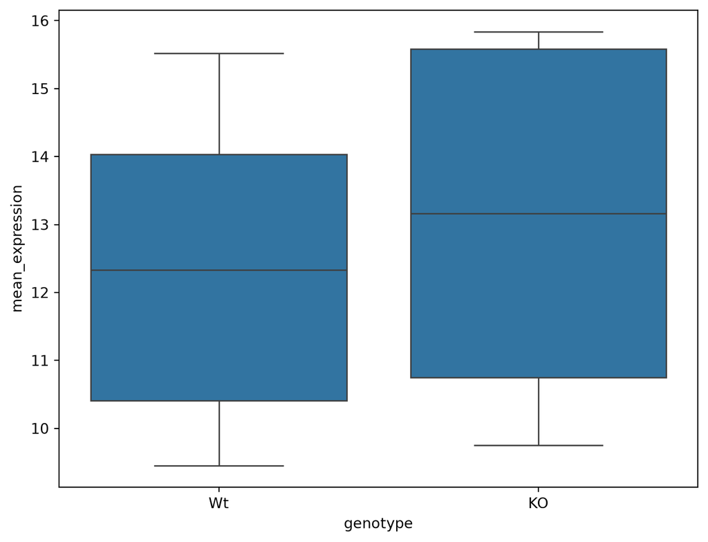

```python
# Initialize a plot with a specific size
plt.figure(figsize = (8, 6))

# Add a boxplot layer to the plot, coloring boxes by celltype
sns.boxplot(data = new_metadata,
            x = "genotype",
            y = "mean_expression")

# Render the plot
plt.show()
```

2. Use the `hue` aesthetic to look at differences in sample means between the celltypes within each genotype.

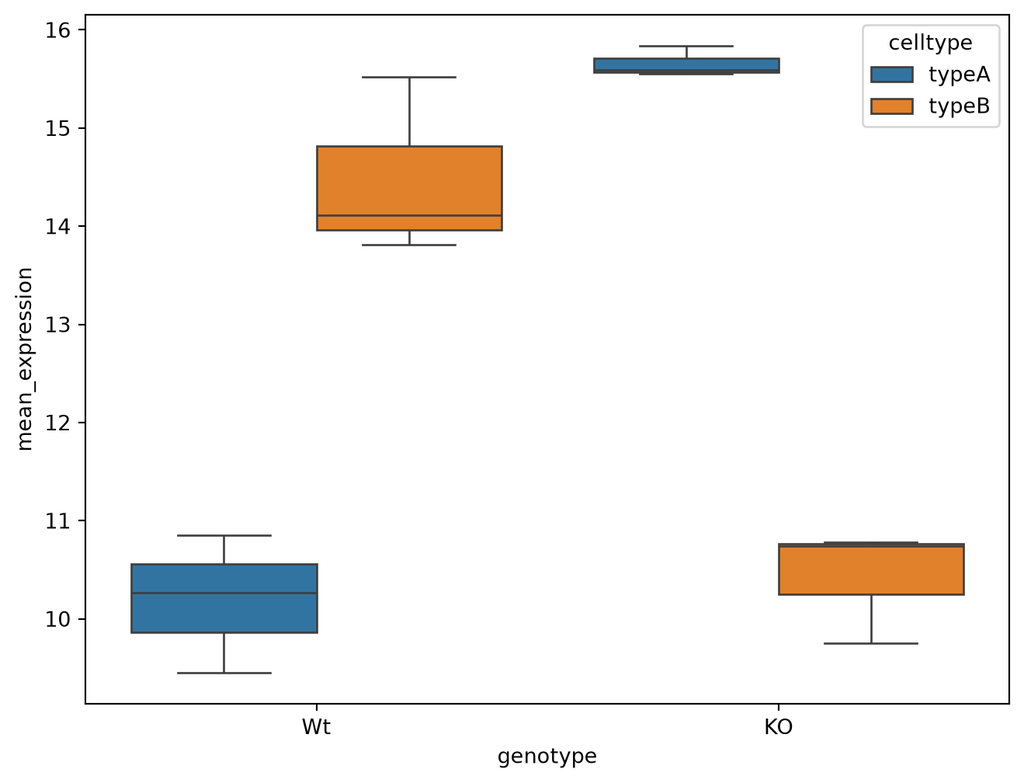

```python
# Initialize a plot with a specific size
plt.figure(figsize = (8, 6))

# Add a boxplot layer to the plot, coloring boxes by celltype
sns.boxplot(data = new_metadata,
            x = "genotype",
            y = "mean_expression",
            hue = "celltype")

# Render the plot
plt.show()
```

3. Add a title to your plot.

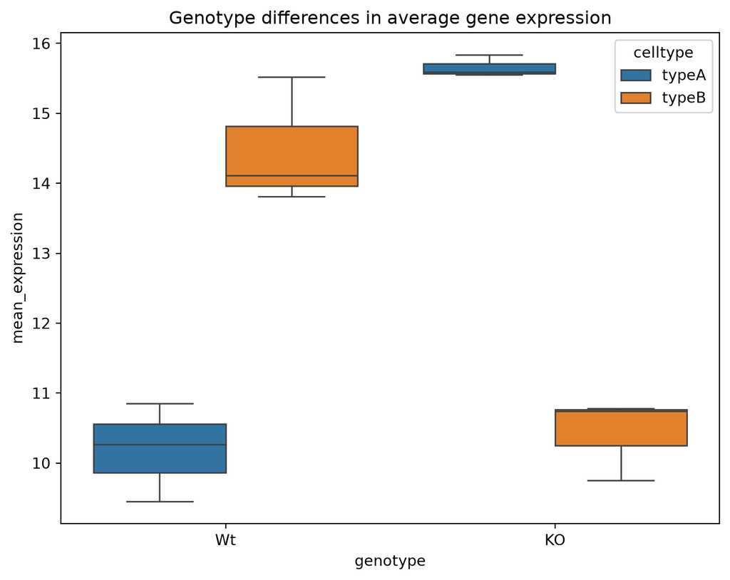

```python
# Initialize a plot with a specific size
plt.figure(figsize = (8, 6))

# Add a boxplot layer to the plot, coloring boxes by celltype
sns.boxplot(data = new_metadata,
            x = "genotype",
            y = "mean_expression",
            hue = "celltype")

# Add plot title
plt.title(label = "Genotype differences in average gene expression")

# Render the plot
plt.show()
```

4. Add labels for the axes, “Genotype” for the x-axis and “Mean expression” for the y-axis.

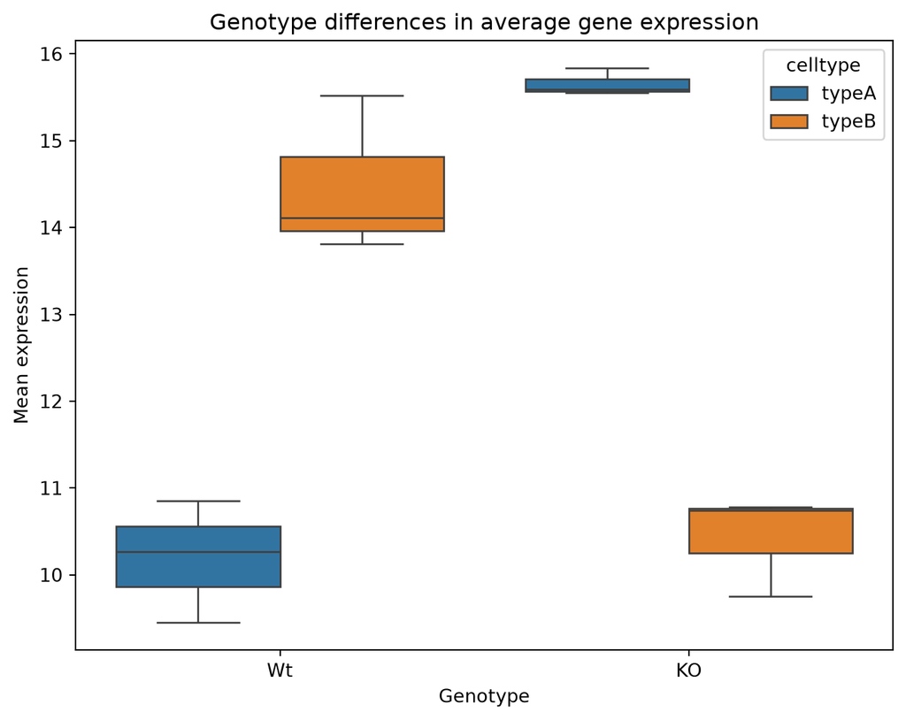

```python
# Initialize a plot with a specific size
plt.figure(figsize = (8, 6))

# Add a boxplot layer to the plot, coloring boxes by celltype
sns.boxplot(data = new_metadata,
            x = "genotype",
            y = "mean_expression",
            hue = "celltype")

# Add plot title
plt.title(label = "Genotype differences in average gene expression")

# Add x-axis label
plt.xlabel(xlabel = "Genotype")

# Add y-axis label
plt.ylabel(ylabel = "Mean expression")

# Render the plot
plt.show()
```

5. Make the following aesthetic changes:
   - Use the `white` `set_style` to make the background white
   - Change the size of your axes labels to 15
   - Change the size of your plot title to 20

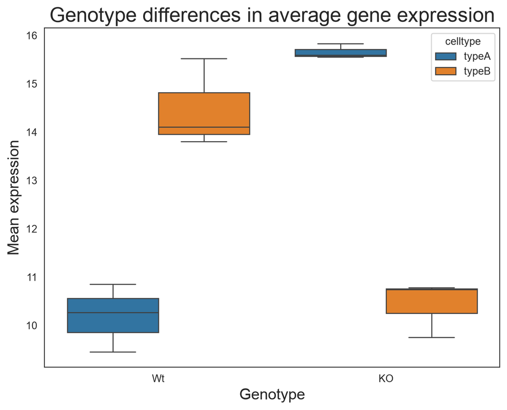

```python
# Set the theme to "white"
sns.set_style(style = "white")

# Initialize a plot with a specific size
plt.figure(figsize = (8, 6))

# Add a boxplot layer to the plot, coloring boxes by celltype
sns.boxplot(data = new_metadata,
            x = "genotype",
            y = "mean_expression",
            hue = "celltype")

# Add plot title
plt.title(label = "Genotype differences in average gene expression",
          fontsize = 20)

# Add x-axis label
plt.xlabel(xlabel = "Genotype",
           fontsize = 15)

# Add y-axis label
plt.ylabel(ylabel = "Mean expression",
           fontsize = 15)

# Render the plot
plt.show()
```

# Exercise 2

There is another argument we can use in `sns.boxplot()` called `order` that allows you to specify the order of the categories on the x-axis.

1. Use the `order` argument to change the order of the genotypes on the x-axis such that `KO` is on the left and `Wt` is on the right.

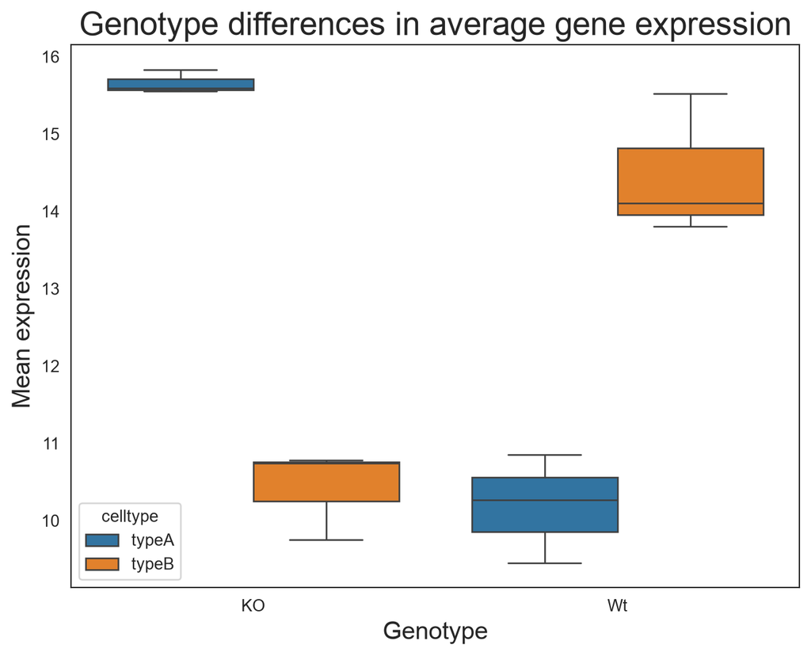

```python
# Set the theme to "white"
sns.set_style(style = "white")

# Initialize a plot with a specific size
plt.figure(figsize = (8, 6))

# Add a boxplot layer to the plot, coloring boxes by celltype
sns.boxplot(data = new_metadata,
            x = "genotype",
            y = "mean_expression",
            hue = "celltype",
            order = ["KO", "Wt"])

# Add plot title
plt.title(label = "Genotype differences in average gene expression",
          fontsize = 20)

# Add x-axis label
plt.xlabel(xlabel = "Genotype",
           fontsize = 15)

# Add y-axis label
plt.ylabel(ylabel = "Mean expression",
           fontsize = 15)

# Render the plot
plt.show()
```

# Exercise 3

1. Specify the argument `palette=["purple","orange"]` in your `sns.boxplot()` code chunk to change the colors of the boxes.

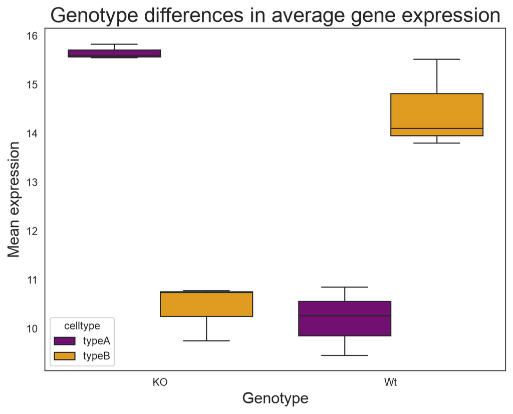

```python
# Set the theme to "white"
sns.set_style(style = "white")

# Initialize a plot with a specific size
plt.figure(figsize = (8, 6))

# Add a boxplot layer to the plot, coloring boxes by celltype
sns.boxplot(data = new_metadata,
            x = "genotype",
            y = "mean_expression",
            hue = "celltype",
            order = ["KO", "Wt"],
            palette = ["purple", "orange"])

# Add plot title
plt.title(label = "Genotype differences in average gene expression",
          fontsize = 20)

# Add x-axis label
plt.xlabel(xlabel = "Genotype",
           fontsize = 15)

# Add y-axis label
plt.ylabel(ylabel = "Mean expression",
           fontsize = 15)

# Render the plot
plt.show()
```

2. Back in your boxplot code, change the colors in the `palette` argument to be your 2 favorite colors. Are there any colors that you tried that did not work? You can try to find some named colors [here](https://matplotlib.org/stable/gallery/color/named_colors.html#css-colors) if you want to explore more colors.

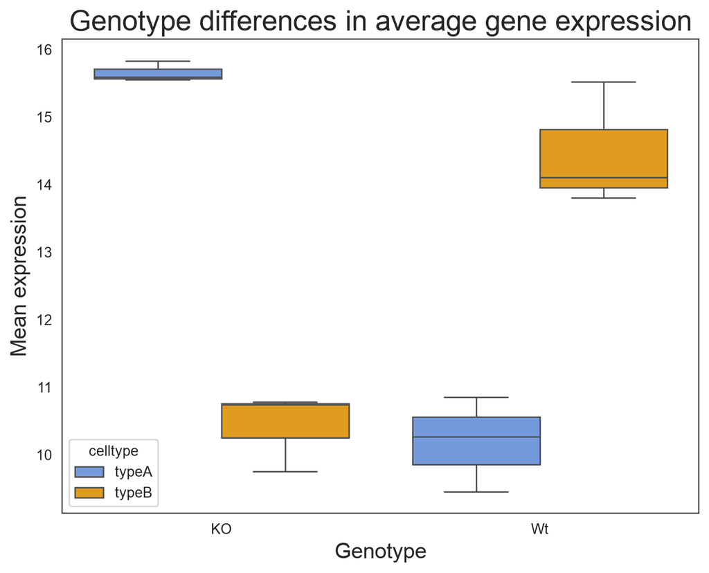

```python
# Set the theme to "white"
sns.set_style(style = "white")

# Initialize a plot with a specific size
plt.figure(figsize = (8, 6))

# Add a boxplot layer to the plot, coloring boxes by celltype
sns.boxplot(data = new_metadata,
            x = "genotype",
            y = "mean_expression",
            hue = "celltype",
            order = ["KO", "Wt"],
            palette = ["cornflowerblue", "orange"])

# Add plot title
plt.title(label = "Genotype differences in average gene expression",
          fontsize = 20)

# Add x-axis label
plt.xlabel(xlabel = "Genotype",
           fontsize = 15)

# Add y-axis label
plt.ylabel(ylabel = "Mean expression",
           fontsize = 15)

# Render the plot
plt.show()
```

`cornflowerblue` is a great color in both R and Python and it exists in both. It also pairs well with `orange` which also exists in both.

# Exercise 4

1. Find the hexadecimal code for your 2 favorite colors (from the previous exercise) and replace the color names with the hexadecimal codes within the code chunk.

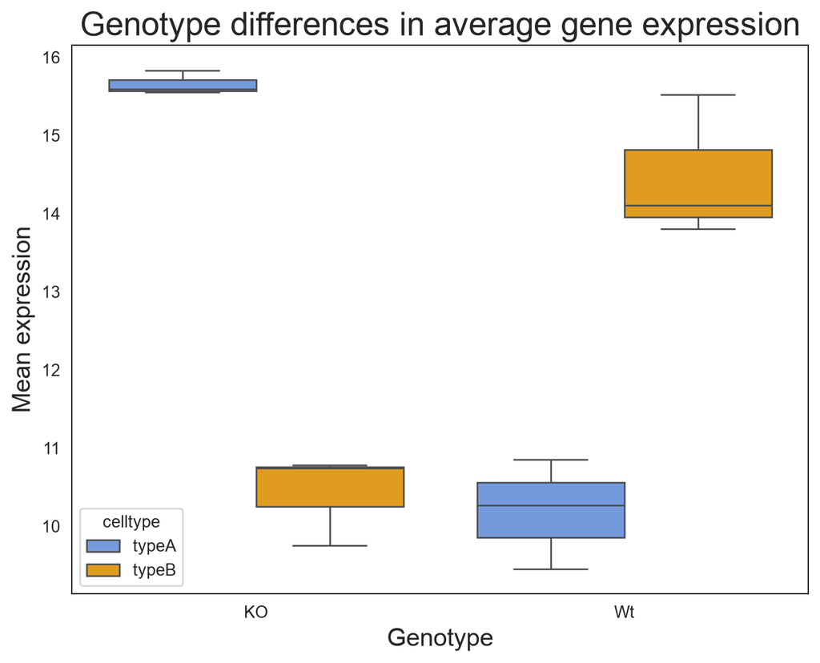

```python
# Set the theme to "white"
sns.set_style(style = "white")

# Initialize a plot with a specific size
plt.figure(figsize = (8, 6))

# Add a boxplot layer to the plot, coloring boxes by celltype
sns.boxplot(data = new_metadata,
            x = "genotype",
            y = "mean_expression",
            hue = "celltype",
            order = ["KO", "Wt"],
            palette = ["#6495ED", "#FFA500"])

# Add plot title
plt.title(label = "Genotype differences in average gene expression",
          fontsize = 20)

# Add x-axis label
plt.xlabel(xlabel = "Genotype",
           fontsize = 15)

# Add y-axis label
plt.ylabel(ylabel = "Mean expression",
           fontsize = 15)

# Render the plot
plt.show()
```